# 3: Functions

R for faculty, Fall 2024

Jonas Moss

# Functions

## What is a function?

**Mathematics:** A function maps each $x$ in $A$ to some unique $y$ in $B$.

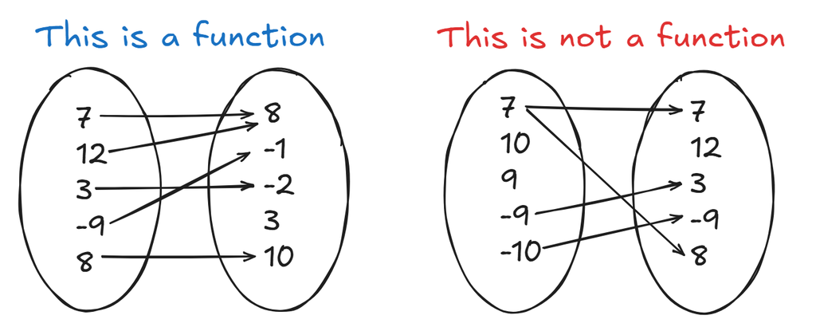

- Functions in programs are *usually* like this.
- The value $y$ is called the return value.
- Classical functions such as $f(x) = x^2 - 1$ are obvious examples, but functions do not need to be described by a formula.
- In many programming languages, functions are called *procedures*.

## Defining functions

**Euclidean norm on $R^2$.** $||x|| = \sqrt{x_1^2+x_2^2}$.

```r
norm <- function(x1, x2) {
  sqrt(x1^2 + x2^2)
}
```

Then we *call* the function:

```r
norm(1, 1)
```

```
[1] 1.414214
```

- Exercise
- Solution

Write a function `norm(x1,x2,x3)` that calculates the Euclidean norm on $\mathbb{R}^3$, $||x|| = \sqrt{x_1^2+x_2^2+x_3^2}$. Calculate the norm of $[1,2,3]$.

```r
norm <- function(x1, x2, x3) {
  sqrt(x1^2 + x2^2 + x3^2)
}

norm(1,2,3)
```

```
[1] 3.741657
```

## Shorthands

Functions can also be written using a shorthand notation:

```r
norm <- \(x, y) {
  sqrt(x^2 + y^2)
}

norm(1,1)
```

```
[1] 1.414214
```

- Exercise
- Solution

Write a function `norm(x1,x2,x3,x4)` that calculates the Euclidean norm on $\mathbb{R}^4$, $||x|| = \sqrt{x_1^2+x_2^2+x_3^2+x_4^4}$. Use the shorthand notation. Calculate the norm of $[1,1,0,1]$.

```r
norm <- \(x1, x2, x3, x4) {
  sqrt(x1^2 + x2^2 + x3^2 + x4^2)
}
norm(1,1,0,1)
```

```
[1] 1.732051
```

## Functions on one line

When functions fit one on line you don’t need the curly braces.

```r
norm <- function(x1, x2, x3) sqrt(x1^2 + x2^2 + x3^2)
```

- Exercise
- Solution

Write the Euclidean norm $||x|| = \sqrt{x_1^2+x_2^2+x_3^2+x_4^4}$ on one line, using the shorthand notation.

```r
norm <- \(x1, x2, x3, x4) sqrt(x1^2 + x2^2 + x3^2 + x4^2)
```

## `\()` vs `function()`

- The `\()` notation is quite new, introduced in 2021.
- Most `R` code uses `function()`.
- I personally prefer `\()`. It’s shorter! `function` is just too long.
- There’s no difference between the choices. Use what you like.
- Exercise
- Solution

Make a function that calculates the signal-to-noise ratio, defined as the mean divided by the standard deviation. (*Hint*: Find R functions that calculate the mean and standard deviation yourself!)

```r
snr <- \(x) mean(x) / sd(x)
```

## Function arguments

Look at the `norm` function once more:

```r
norm <- \(x1, x2, x3) sqrt(x1^2 + x2^2 + x3^2)
```

Here `x1`, `x2`, and `x3` are the *arguments* of the function

- Exercise
- Solution

What’s wrong with following function definition?

```r
f <- \(a,b) {
  a + B
}
```

`B` is not an argument of the function – but `b` is!

```r
f <- \(a,b) {
  a + b
}
```

## Function composition

```r
square <- \(x) x^2
deviation <- \(x) x - mean(x)
```

The biased sample variance equals

```r
x <- mtcars$mpg
mean(square(deviation(x)))
```

```
[1] 35.18897
```

## Exercise time

Let’s get comfy with functions through exercises.

- Ex. 1
- Sol. 1
- Ex. 2
- Sol. 2
- Ex. 3
- Sol. 3
- Ex. 4
- Sol. 4

Write a function `summer` that calculates the sum of the first $n$ natural numbers, i.e., `1,2,\ldots,n`.

```r
summer <- \(n) sum(seq(n))
summer2 <- \(n) (n*(n+1))/2
```

Write a function `hn` that calculates the $n$th *harmonic number*, i.e., $H_n=1/1 + 1/2 + 1/n$. (*Hint*: What happens to `1/seq(n)`?)

```r
hn <- \(n) sum(1/seq(n))
```

A famous approximation to the $n$th harmonic number states that $H_n \approx \log(n)+\gamma$, where $\gamma$ is the Euler–Mascheroni constant. (`-digamma(1)` in `R`).

Write a function `h_n_approx` that returns the approximation to $H_n$. Verify it on `n=1000`.

```r
hn_approx <- \(n) log(n) - digamma(1)
hn_approx(1000)
```

```
[1] 7.484971
```

```r
hn(1000)
```

```
[1] 7.485471
```

Write a function `is_awesome(x)` that returns `"LOL"` if its input is `"MrBeast"` and `"Boring!"` otherwise. Test the function on `"MrBeast"` and `"William Shakespeare"`.

```r
is_awesome <- \(x) {
  if (x == "MrBeast") {
    "LOL"
  } else {
    "Boring!"
  }
}

is_awesome("MrBeast")
```

```
[1] "LOL"
```

```r
is_awesome("William Shakespeare")
```

```
[1] "Boring!"
```

## Loops and functions

- Loops and functions
- Exercise
- Solution

Functions are often used to “hide” information from the user, such as loops.

We may sum the values of a vector as follows:

```r
summer <- \(x) {
  adder = 0
  for (i in x) {
    adder = adder + i
  }
  adder
}
```

```r
summer(1:20)
```

```
[1] 210
```

```r
summer(5:11)
```

```
[1] 56
```

Using `for` loops, make a function `maxi` that returns the maximal value of a vector. Test it on `x<-c(1,2,10,-1,0)`. You must use conditionals here.

```r
maxi <- \(x) {
  current = 0
  for (i in x) {
    if (i > current) {
      current = i
    }
  }
  current
}
maxi(c(1,2,10,-1,0))
```

```
[1] 10
```

## Missing number

Programming requires thinking.

We have the tools for solving the next exercise!

- Exercise
- Solution
- Exercise
- Solution

Suppose that `x` is a vector of numbers `1,2,...,n`, but one number **less than `n`** is missing. Make a function `get_missing` that returns the missing number.

```r
x <- c(1,2,4,5)
get_missing(x) # 3
```

```r
x <- c(1,2,4,5)
get_missing <- \(x) sum(seq_len(max(x))) - sum(x)
get_missing(x)
```

```
[1] 3
```

Suppose that `x` is a vector of numbers `1,2,...,n`, but with one number. Make a function `get_missing2` that returns the missing number.

```r
get_missing2 <- \(x) {
  if (max(x) == length(x)) {
    length(x) + 1
  } else {
    get_missing(x)
  }
}
get_missing2(c(1,2,4,5))
```

```
[1] 3
```

```r
get_missing2(c(1,2,3,4,5))
```

```
[1] 6
```

## Explicit returns

`R` returns the last calculated value of a function, but you can also return explicitly.

```r
is_awesome <- \(x) {
  if (x == "MrBeast") {
    return("LOL")
  }
  "Boring"
}
```

- Exercise
- Solution

```r
get_non_zero <- \(x) {
  if (x == 0) {
    return(NULL)
  }
  x
}
```

## Function scope

The values defined in a function are *private* to that function – they belong to the function’s private *scope*.

- Exercise
- Solution
- Exercise
- Solution
- Exercise
- Solution

What value of `x` is printed?

```r
f <- \() {
  x <- 55
  x
}

x = 0
f()
print(x)
```

The solution is `0`, as the `x` inside `f` belongs to that function’s scope.

What value will `f(1, 2)` return?

```r
f <- \(a,b) {
  a + b
}

a <- 55
```

`f` returns `3`, since `a` is an argument.

What value will `f(1, 0)` return? Or will it work at all?

```r
f <- \(a, b) {
  a + B
}

B <- 2
```

```r
f(1, 0)
```

[output not shown]

The function `f` doesn’t use its second argument, but it does use `B`! It can use `B` because it exists in its defining environment. (Functions having this property are called *closures*.)

## Functions in `R`

- Writing your own functions is important.
- But it’s even more important to become familiar with `R`s built-in functions.
- You need to look at the documentation (write `?fun` in the terminal) and look up stuff at the internet.
- Looking up the documentation is better!
- Exercise
- Solution

Figure out what the following the functions `rev(y)` and `sort(y)` do. How do you sort `y` in decreasing order? Let `y=c(4,6,2,1)` for simplicity. (There are two ways to do this!)

```r
y=c(4,6,2,1)
sort(y, decreasing = TRUE)
```

```
[1] 6 4 2 1
```

```r
rev(sort(y))
```

```
[1] 6 4 2 1
```

# More functions

## Side-effects and pure functions

- In mathematics a function $f:X\to Y$ is a “rule” that sends an object in $X$ to an object in $Y$.
- Such functions exist in `R` and other programming languages too; they are called *pure*.
- But functions can do other stuff as well. Such “other stuff” is called *side effects*.
- Exercise
- Solution

What does this function do?

```r
f <- \(x) {
  print(paste0("I love ", x+1, "!"))
  x+3
}
```

```r
2 + f(3)
```

```
[1] "I love 4!"
```

```
[1] 8
```

## Closures

A function can access the variables in its *defining environment*, but will not modify them.

- A function
- Another function
- Exercise
- Solution

```r
t <- 55
f <- \(x) {
  x + t
}
f(3)
```

```
[1] 58
```

```r
t <- 55
f <- \(x) {
  print(paste0("Now t=", t, "."))
  t <- pi
  print(paste0("But now, t=", t, "!"))
  x
}
f(7)
```

```
[1] "Now t=55."
[1] "But now, t=3.14159265358979!"
```

```
[1] 7
```

```r
t
```

```
[1] 55
```

Here `f` was able to access `t=55` from its *defining enviroment*. But it can’t (easily!) modify the value of `t` in its calling environment.

What happens when we run the following code?

```r
i <- 5
f <- \(i) {
  i <- i
  i
}
print(f(3))
print(i)
```

Function arguments always take precedence over values in the calling environment!

```r
i <- 5
f <- \(i) {
  i <- i
  i
}
print(f(3))
```

```
[1] 3
```

```r
print(i)
```

```
[1] 5
```

## Using `<<-`

You *can* modify variables in the calling environment using functions. To do this, use `<<-`. This is *very rarely useful*!

```r
x <- 55
f <- \(y) {
  x <<- y
}
print(x)
```

```
[1] 55
```

```r
f(13)
print(x)
```

```
[1] 13
```

## Returning functions

Take a look at the following function.

```r
factory <- \(x) {
  adder <- \(y) x + y
  adder
}
```

What is this?

```r
f <- factory(1)
f
```

```
function (y)
x + y
<environment: 0x000001ed3d478e98>
```

- Exercise
- Solution

Use the `f` to calculate the sum `1+2`.

```r
factory(1)(2)
```

```
[1] 3
```

## Application

- Recall the Newton–Raphson method from calculus.
- We have a function $f(x)$ and want to find the unique $x$ where $x=0$.
- To to this, we use the iterates $x_{i+1} = x_i - \frac{f(x_i)}{f'(x_i)}$, where $f'$ is the derivative of $f$.
- We continue the iteration until $|x_{i+1} - x_i|/|x_i| < \epsilon$ for some small $\epsilon$.

## The square root

- Procedure
- Exercise
- Solution
- The square root of a number $a$ is the unique real solution to $x^2 -a = 0$.
- Let’s write a Newton–Raphson method for calculating the square root of $2$.

```r
f <- \(x) x^2 - 2
df <- \(x) 2*x
x0 <- 2
epsilon <- 10
while (epsilon > 0.000001) {
  x1 <- x0 - f(x0) / df(x0)
  epsilon = abs(x1-x0) / abs(x0)
  x0 <- x1
}
x0 - sqrt(2)
```

```
[1] 0
```

Make a function `square_root(a, x0, eps)` that calculates the square root of `a` using Newton–Raphson. (Here `x0` is the starting value and `epsilon` is the desired accuracy.) Give `x0` a default value of `1` and `epsilon` a default value of `0.000001`.

```r
square_root <- \(a, x0 = 1, eps = 0.000001) {
  f <- \(x) x^2 - a
  df <- \(x) 2*x
  epsilon <- 10
  while (epsilon > eps) {
    x1 <- x0 - f(x0) / df(x0)
    epsilon = abs(x1-x0) / abs(x0)
    x0 <- x1
  }
  x0
}
```

## Documentation

- Functions should always be documented.
- There is a standardized way to document functions and other `R` objects.
- It is called `Roxygen`. Documentation comments start with `#'`.

```r
#' Estimate signal-to-noise ratio.
#' @param x Vector of observations.
#' @returns Estimated signal-to-noise ratio.
snr <- \(x) {
  mean(x) / sd(x)
}
```

- Exercise
- Solution

Write a function `mad2` that estimates the [*mean absolute deviation from the median*](https://en.wikipedia.org/wiki/Average_absolute_deviation#Median_absolute_deviation_around_the_median). Write documentation for the function.

```r
#' Estimate the mean absolute deviation from the median
#' @param x Vector of observations.
#' @returns The mean absolute deviation from the median.
mad <- \(x) mean(x - median(x))
```

## Comments and documentation

- Its common advice to place plenty of comments in your code.
- I’d suggest you avoid comments as much as you can. Write *documentation* instead!

## The `...` arguments (dot-dot-dot)

Look at the documentation `?sum`. The argument `...` tells `R` the function takes an arbitrary number of arguments, named or not.

## Optimization

- Recall that the maximum likelihood estimator of a density family $f(x;\theta)$ on the data $x_1,\ldots,x_n$ is the $\theta$ that maximimes $\sum_{i=1}^n \log f(x_i;\theta)$.
- The `nlm` function (non-linear minimization) does function minimization for you. It usually works well, but there are better, bespoke methods.

```r
x <- univariateML::egypt$age
f <- \(p) -sum(dweibull(x, p[1], p[2], log = TRUE))
nlm(f, c(1, 1))$estimate
```

```
[1]  1.404159 33.563594
```

- Exercise
- Solution

Compare to `nlm` solution above to the bespoke solution `mlweibull` in the `univariateML` package.

```r
univariateML::mlweibull(x)
```

```
Maximum likelihood estimates for the Weibull model
 shape   scale
 1.404  33.564
```

# Summary

1. Functions are defined using `\() {}` or `function() {}`.
2. Document your functions using `Roxygen`.
3. Most “natural” statistical functions are already implemented in `R`.
4. You need to write loads of functions to get good at programming. *Deliberate practice.*